## **Assignment Four: Qualitative Variables**

# Labor markets and returns to schooling

For this problem you will use the dataset supplied via Canvas, filename: “card.dta”, which is taken from Card, David (1995) “Using Geographic Variation in College Proximity to Estimate the Returns to Schooling," in Aspects of Labour Market Behavior: Essays in Honour of John Vanderkamp, ed. L. H. Christophides, E. K. Grand, and R. Swidinsky. Toronto: University of Toronto Press: 201-222. The data measure a variety of characteristics of individuals and include data on the proximity of two- and four-year colleges.

Familiarize yourself with the data based on the accompanying PDF of Card’s working paper (look it up online, it is a old but good paper). Note where the data are originally from, what kind of sampling was involved, and the units of observation.

Pay particular attention to the following variables and ensure you know what they measure and in what units: wage, educ, exper, exper2. You may have to infer the units of measurement from the variable distributions.

For your writeup, present a table that shows sample means, standard deviations, and minimum/maximum values for the wage, educ, exper variables (call this Table 1). In a note to this table, say how many observations are in the dataset and how many variables there are. Also present a scatter plot of wage by education in a way you think makes sense. Call this Figure 5.

Run the following regressions:

Specification 1: $ln(wage)=\beta_0+\beta_1 (educ)+u_i$

Specification 2: $ln(wage)=\beta_0+\beta_1 (educ)+\beta_2 (exper)+u_i$

Specification 3: $ln(wage)=\beta_0+\beta_1 (educ)+\beta_2 (exper)+\beta_3 (expersq)+u_i$

Specification 4: $ln(wage)=\beta_0+\beta_1 (educ)+ \beta_2 (exper)+ \beta_3 (expersq)+\beta_4 (married)+u_i$

Specification 5: $ln(wage)=\beta_0+\beta_1 (educ)+ \beta_2 (exper)+ \beta_3 (expersq)+\beta_4 (married)+\beta_5(black)+u_i$

- For the married variable show two different ways of creating a dummy variable to incorporate it in your regression. The new variables is such that 1 is married and 0 otherwise. Make your dummy based on the description from this [link](https://usa.ipums.org/usa-action/variables/MARST#codes_section) married only counts when spouse present.
- Present a regression output table (Table 2). Below the set of tables, provide discussion of the parameter estimates for Specification 5 (interpret the fitted values for $\beta_0$,$\beta_1$,$\beta_2$,$\beta_3$,$\beta_4$,$\beta_5$). Comment on any major changes you see between Specification 5 and Specification 2.
- When a worker gains one more year of experience, by how much is the wage expected to increase, on average? Discuss differences in the parameter estimates in specifications 2 and 3. (Hint: Take the derivative of each with respect to experience.)
- State the first two algebraic properties of the OLS estimator. Verify that these properties hold in Specification 1 and Specification 5. *(Hint: You will be able to do this by predicting the residuals into the data, and then using the “sum” function on the variables.)*

**All your models should be presented only in a stargazer table. Make sure you do that part before this homework.**

**Do your best to NOT use AI for this assignment but be honest stating if you do.**

```python
import wooldridge as woo
import numpy as np
import pandas as pd
import seaborn as sns
import matplotlib.pyplot as plt

import statsmodels.api as sm
import statsmodels.formula.api as smf
import scipy.stats as stats

from stargazer.stargazer import Stargazer
from IPython.core.display import HTML
pd.options.display.float_format = '{:.3f}'.format
```

```python
data = pd.read_stata('card.dta')
display(data.info())
data.describe()
```

```
<class 'pandas.core.frame.DataFrame'>
RangeIndex: 3010 entries, 0 to 3009
Data columns (total 34 columns):
 #   Column    Non-Null Count  Dtype
---  ------    --------------  -----
 0   id        3010 non-null   int16
 1   nearc2    3010 non-null   int8
 2   nearc4    3010 non-null   int8
 3   educ      3010 non-null   int8
 4   age       3010 non-null   int8
 5   fatheduc  2320 non-null   float64
 6   motheduc  2657 non-null   float64
 7   weight    3010 non-null   float32
 8   momdad14  3010 non-null   int8
 9   sinmom14  3010 non-null   int8
```

[output cut: 26 more lines]

```
None
```

|  | id | nearc2 | nearc4 | educ | age | fatheduc | motheduc | weight | momdad14 | sinmom14 | ... | smsa66 | wage | enroll | kww | iq | married | libcrd14 | exper | lwage | expersq |
| --- | --- | --- | --- | --- | --- | --- | --- | --- | --- | --- | --- | --- | --- | --- | --- | --- | --- | --- | --- | --- | --- |
| count | 3010.000 | 3010.000 | 3010.000 | 3010.000 | 3010.000 | 2320.000 | 2657.000 | 3010.000 | 3010.000 | 3010.000 | ... | 3010.000 | 3010.000 | 3010.000 | 2963.000 | 2061.000 | 3003.000 | 2997.000 | 3010.000 | 3010.000 | 3010.000 |
| mean | 2581.749 | 0.441 | 0.682 | 13.263 | 28.120 | 10.003 | 10.348 | 321185.250 | 0.789 | 0.101 | ... | 0.650 | 577.282 | 0.092 | 33.541 | 102.450 | 2.271 | 0.674 | 8.856 | 6.262 | 95.579 |
| std | 1500.539 | 0.497 | 0.466 | 2.677 | 3.137 | 3.721 | 3.180 | 170645.922 | 0.408 | 0.301 | ... | 0.477 | 262.958 | 0.290 | 8.612 | 15.424 | 2.067 | 0.469 | 4.142 | 0.444 | 84.618 |
| min | 2.000 | 0.000 | 0.000 | 1.000 | 24.000 | 0.000 | 0.000 | 75607.000 | 0.000 | 0.000 | ... | 0.000 | 100.000 | 0.000 | 4.000 | 50.000 | 1.000 | 0.000 | 0.000 | 4.605 | 0.000 |
| 25% | 1275.500 | 0.000 | 0.000 | 12.000 | 25.000 | 8.000 | 8.000 | 122798.000 | 1.000 | 0.000 | ... | 0.000 | 394.250 | 0.000 | 28.000 | 93.000 | 1.000 | 0.000 | 6.000 | 5.977 | 36.000 |
| 50% | 2541.000 | 0.000 | 1.000 | 13.000 | 28.000 | 10.000 | 12.000 | 365200.000 | 1.000 | 0.000 | ... | 1.000 | 537.500 | 0.000 | 34.000 | 103.000 | 1.000 | 1.000 | 8.000 | 6.287 | 64.000 |
| 75% | 3858.750 | 1.000 | 1.000 | 16.000 | 31.000 | 12.000 | 12.000 | 406024.000 | 1.000 | 0.000 | ... | 1.000 | 708.750 | 0.000 | 40.000 | 113.000 | 4.000 | 1.000 | 11.000 | 6.564 | 121.000 |
| max | 5225.000 | 1.000 | 1.000 | 18.000 | 34.000 | 18.000 | 18.000 | 1752340.000 | 1.000 | 1.000 | ... | 1.000 | 2404.000 | 1.000 | 56.000 | 149.000 | 6.000 | 1.000 | 23.000 | 7.785 | 529.000 |

8 rows × 34 columns

## 1) Here, I will create a table that shows sample means, standard deviations, and minimum/maximum values for the wage, educ, exper variables. I will also state how many observations are in this dataset, and the number of variables. Finally, below that I will create the scatterplot of wage by education

```python
#Table, # of observations, # of variables
summary = data[['wage', 'educ', 'exper']].describe().T
summary.describe()
summary = summary[['mean', 'std', 'min', 'max']]
summary.columns = ['Mean', 'Standard Deviation', 'Minimum', 'Maximum']
print(summary)
num_obs = len(data)
num_vars = data.shape[1]
print(f"\nNote: The dataset contains {num_obs} observations and {num_vars} variables.")
```

```
         Mean  Standard Deviation  Minimum  Maximum
wage  577.282             262.958  100.000 2404.000
educ   13.263               2.677    1.000   18.000
exper   8.856               4.142    0.000   23.000

Note: The dataset contains 3010 observations and 34 variables.
```

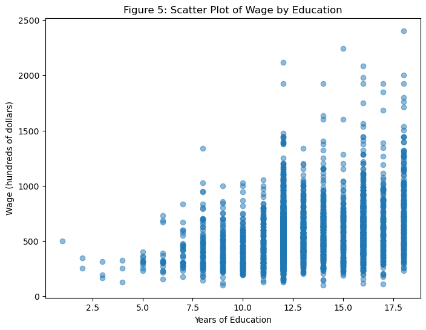

```python
#Scatter plot
plt.figure(figsize=(8, 6))
plt.scatter(data['educ'], data['wage'], alpha=0.5)
plt.xlabel("Years of Education")
plt.ylabel("Wage (hundreds of dollars)")
plt.title("Figure 5: Scatter Plot of Wage by Education")
plt.show()
```

## 2) Here, I will run all 5 regressions and create the regression output table using stargazer

```python
data['ln_wage'] = np.log(data['wage'])
spec1 = smf.ols('ln_wage ~ educ', data=data).fit()
spec2 = smf.ols('ln_wage ~ educ + exper', data=data).fit()
data['expersq'] = data['exper'] ** 2
spec3 = smf.ols('ln_wage ~ educ + exper + expersq', data=data).fit()
spec4 = smf.ols('ln_wage ~ educ + exper + expersq + married', data=data).fit()
spec5 = smf.ols('ln_wage ~ educ + exper + expersq + married + black', data=data).fit()
models = Stargazer([spec1, spec2, spec3, spec4, spec5])
models.title('Regression Analysis of Returns to Schooling: Impact of College Proximity')
models.custom_columns(['spec1', 'spec2', 'spec3', 'spec4', 'spec5'], [1, 1, 1, 1,1])
models.covariate_order(['Intercept', 'educ' , 'exper' , 'expersq', 'married', 'black'])
HTML(models.render_html())
```

|  | *Dependent variable: ln_wage* |  |  |  |  |
| --- | --- | --- | --- | --- | --- |
|  | spec1 | spec2 | spec3 | spec4 | spec5 |
|  | (1) | (2) | (3) | (4) | (5) |
| Intercept | 5.571*** | 4.666*** | 4.635*** | 4.821*** | 4.992*** |
|  | (0.039) | (0.064) | (0.065) | (0.066) | (0.066) |
| educ | 0.052*** | 0.093*** | 0.094*** | 0.090*** | 0.080*** |
|  | (0.003) | (0.004) | (0.004) | (0.004) | (0.004) |
| exper |  | 0.041*** | 0.042*** | 0.036*** | 0.036*** |
|  |  | (0.002) | (0.002) | (0.002) | (0.002) |
| expersq |  |  | 0.000** | 0.000** | 0.000** |
|  |  |  | (0.000) | (0.000) | (0.000) |
| married |  |  |  | -0.037*** | -0.032*** |
|  |  |  |  | (0.004) | (0.004) |
| black |  |  |  |  | -0.214*** |
|  |  |  |  |  | (0.017) |
| Observations | 3010 | 3010 | 3010 | 3003 | 3003 |
| R<sup>2</sup> | 0.099 | 0.181 | 0.183 | 0.212 | 0.249 |
| Adjusted R<sup>2</sup> | 0.098 | 0.181 | 0.182 | 0.211 | 0.248 |
| Residual Std. Error | 0.421 (df=3008) | 0.402 (df=3007) | 0.401 (df=3006) | 0.394 (df=2998) | 0.385 (df=2997) |
| F Statistic | 329.537*** (df=1; 3008) | 332.998*** (df=2; 3007) | 224.511*** (df=3; 3006) | 201.134*** (df=4; 2998) | 199.229*** (df=5; 2997) |
| Note: | *p<0.1; **p<0.05; ***p<0.01 |  |  |  |  |

## 3) Here, I will show 2 ways to create the dummy variable for marriage(Used AI for this part)

```python
#Method 1:
data['married(1)'] = np.where(data['married'] == 'Married, spouse present', 1, 0)
#Method 2:
data['married(2)'] = data['married'].apply(lambda x: 1 if x == 1 else 0)
```

Comparison: For educ, it decreased from specification 2 to specification 5. This implies that some of the other variables added in specification 5 explain some of the educational impact on wages. Same goes for experience. The addition of expersq, married, and black allow for the data to be better explained as there is more insight into what affects wage. We see that through the R^2 increasing from 0.181 to 0.249.

## 5) Here, I will talk about the differences in experience between specification 2 and 3.

For specification 2, it is very simple to see the change in wage for every extra year of experience because it is just the coefficient. Ini specification 2, for every extra year of experience an individual has, their wages are expected to increase about 4.1%. For specification 3, it is more complicated because there are 2 exper variables. One is squared, which does not allow for multicollinearity. To find the effect of wages for specification 3, we must take the derivative of the equation with respect to experience. After doing so, we end up with 0.042 + (2 * 0). This results in 0.042. Therefore, for specification 3, every extra year of experience an individual has leads to a 4.2% increase in their wage. The difference in the effects of wages between these specificaitons are very minimal.

## 6) Here, I will state the algebraic properties of the OLS estimator, and then I will prove that they hold for specifications 1 and 5.

Algebraic property 1: The first property for OLS is that the deviations from regression line up to zero Algebraic property 2: The covariance betweeen deviations and regressors are zero.

```python
data['residuals_spec1'] = spec1.resid
data['residuals_spec5'] = spec5.resid

#Property 1: Sum of residuals is zero
sum_resid_spec1 = data['residuals_spec1'].sum()
sum_resid_spec5 = data['residuals_spec5'].sum()
print(f"Sum of residuals (Specification 1): {sum_resid_spec1:.3f}")
print(f"Sum of residuals (Specification 5): {sum_resid_spec5:.3f}")

#Property 2: Residuals uncorrelated with independent variables
# Spec 1
educ_correlation_spec1 = (data['residuals_spec1'] * data['educ']).sum()
print(f"Sum of residuals * educ (Specification 1): {educ_correlation_spec1:.3f}")

# Spec 5
educ_correlation_spec5 = (data['residuals_spec5'] * data['educ']).sum()
exper_correlation_spec5 = (data['residuals_spec5'] * data['exper']).sum()
expersq_correlation_spec5 = (data['residuals_spec5'] * data['expersq']).sum()
married_correlation_spec5 = (data['residuals_spec5'] * data['married']).sum()
black_correlation_spec5 = (data['residuals_spec5'] * data['black']).sum()
print(f"Sum of residuals * educ (Specification 5): {educ_correlation_spec5:3f}")
print(f"Sum of residuals * exper (Specification 5): {exper_correlation_spec5:.3f}")
print(f"Sum of residuals * expersq (Specification 5): {expersq_correlation_spec5:.3f}")
print(f"Sum of residuals * married (Specification 5): {married_correlation_spec5:.3f}")
print(f"Sum of residuals * black (Specification 5): {black_correlation_spec5:.3f}")
```

```
Sum of residuals (Specification 1): 0.000
Sum of residuals (Specification 5): -0.000
Sum of residuals * educ (Specification 1): 0.000
Sum of residuals * educ (Specification 5): 0.000000
Sum of residuals * exper (Specification 5): -0.000
Sum of residuals * expersq (Specification 5): 0.000
Sum of residuals * married (Specification 5): 0.000
Sum of residuals * black (Specification 5): -0.000
```